# Check the cell type composition estimates

# Load required library

```r
library(data.table)
library(R.utils)
library(ICeDT)
library(ggcorrplot)
```

# CIBERSORT Results

Read CIBERSORT cell fraction estimates.

```r
CBST_folder = "./CIBERSORT/CIBERSORTx_output"

cb_LM22    = fread(file.path(CBST_folder, "CIBERSORTx_LM22_Adjusted.txt"))
cb_SF2018  = fread(file.path(CBST_folder, "CIBERSORTx_SF2018_Adjusted.txt"))

pancan_file = "pan_cancer_data/TCGA.Kallisto.fullIDs.cibersort.relative.tsv"
cb_panCan   = fread(pancan_file)

dim(cb_LM22)
```

```
## [1] 472  26
```

```r
cb_LM22[1:2,c(1:2,23:26)]
```

| Mixture | B.cells.naive | Neutrophils | P-value | Correlation | RMSE |
| --- | --- | --- | --- | --- | --- |
| TCGA.D3.A8GB.06A | 0.067447854 | 8.560123e-06 | 0 | 0.5379340 | 0.8460075 |
| TCGA.WE.A8ZN.06A | 0.006532623 | 0.000000e+00 | 0 | 0.7292759 | 0.7352293 |

```r
dim(cb_SF2018)
```

```
## [1] 472  15
```

```r
cb_SF2018[1:2,c(1:2,12:15)]
```

| Mixture | B_cells | Tregs | P-value | Correlation | RMSE |
| --- | --- | --- | --- | --- | --- |
| TCGA.D3.A8GB.06A | 0.08080847 | 0.05315502 | 0 | 0.6085551 | 0.7955245 |
| TCGA.WE.A8ZN.06A | 0.00000000 | 0.04265127 | 0 | 0.1696071 | 1.0415445 |

```r
table(cb_panCan$Mixture == cb_SF2018$Mixture)
```

```
## < table of extent 0 >
```

```r
dim(cb_panCan)
```

```
## [1] 11373    27
```

```r
cb_panCan[1:2,c(1:2,12:15)]
```

| SampleID | CancerType | T.cells.gamma.delta | NK.cells.resting | NK.cells.activated | Monocytes |
| --- | --- | --- | --- | --- | --- |
| TCGA.OR.A5JG.01A.11R.A29S.07 | ACC | 0 | 0.02915768 | 0.04316658 | 0.04670290 |
| TCGA.OR.A5LG.01A.11R.A29S.07 | ACC | 0 | 0.00790617 | 0.03155757 | 0.06811697 |

```r
cb_panCan$Mixture = substr(cb_panCan$SampleID, 1, 16)
table(cb_LM22$Mixture %in% cb_panCan$Mixture)
```

```
##
## TRUE
##  472
```

```r
cb_panCan = cb_panCan[match(cb_LM22$Mixture, cb_panCan$Mixture),]

dim(cb_panCan)
```

```
## [1] 472  28
```

```r
cb_panCan[1:2,c(1:4,24:28)]
```

| SampleID | CancerType | B.cells.naive | B.cells.memory | Neutrophils | P.value | Correlation | RMSE | Mixture |
| --- | --- | --- | --- | --- | --- | --- | --- | --- |
| TCGA.D3.A8GB.06A.11R.A37K.07 | SKCM | 0.03728691 | 0.03748955 | 0 | 0.046 | 0.1705207 | 1.029100 | TCGA.D3.A8GB.06A |
| TCGA.WE.A8ZN.06A.11R.A37K.07 | SKCM | 0.00000000 | 0.03875615 | 0 | 0.018 | 0.2212282 | 1.004304 | TCGA.WE.A8ZN.06A |

Boxplot of cell fraction for each cell type inferred using LM22 signature matrix by CIBERSORTx

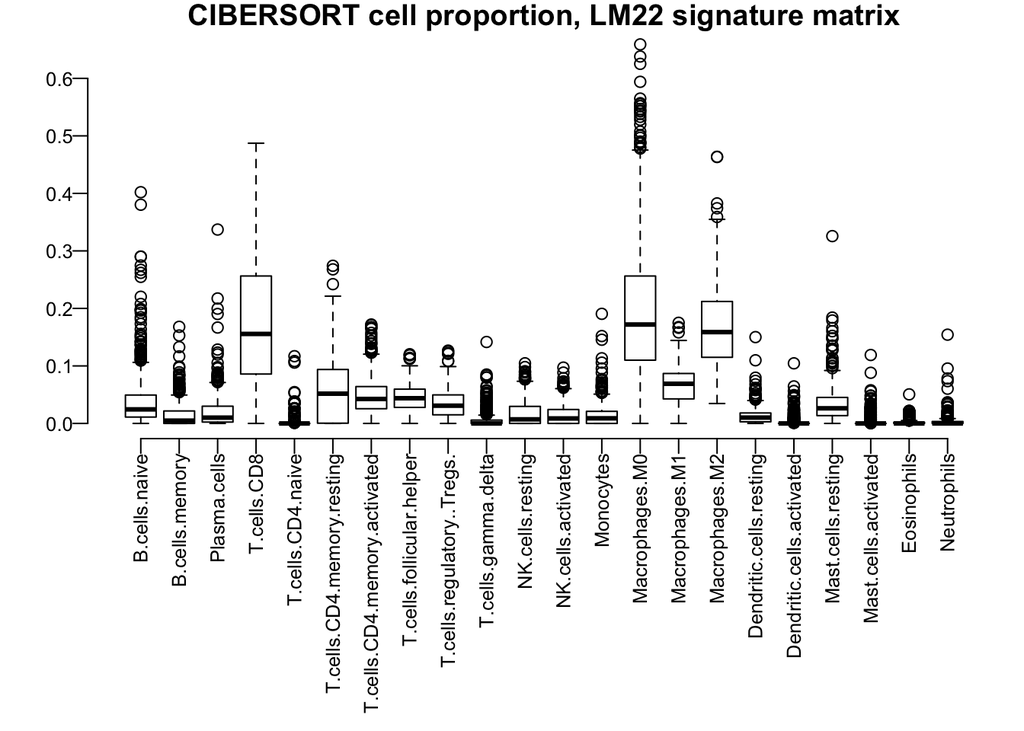

```r
par(mar=c(10,3,1,0.8), mgp=c(1.5,0.5,0), cex.axis=0.8, bty="n")
boxplot(cb_LM22[,2:23],las=2,
        main="CIBERSORT cell proportion, LM22 signature matrix")
```

Boxplot of cell fraction for each cell type inferred using SF2018 signature matrix by CIBERSORTx

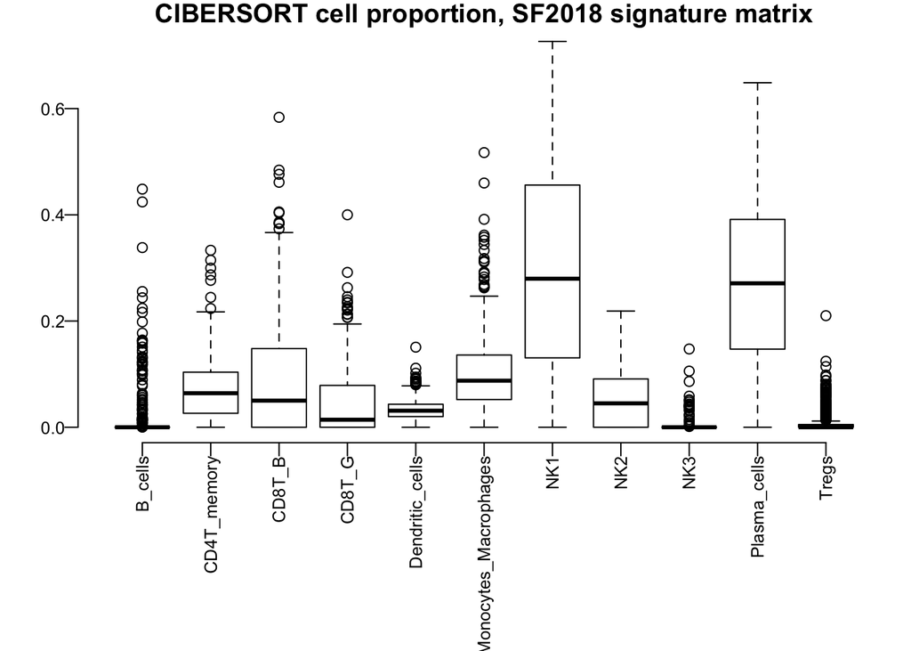

```r
par(mar=c(8,3,1,0.8), mgp=c(1.5,0.5,0), cex.axis=0.8, bty="n")
boxplot(cb_SF2018[,2:12], las=2,
        main="CIBERSORT cell proportion, SF2018 signature matrix")
```

Correlation plot compare cell fractions inferred using LM22 signature matrix and SF2018 signature matrix in CIBERSORTx  
- For most of the cell types, we see the fractions inferred using different signature matrix correlated - Fractions of dendritic cell inferred using the 2 types of signature matrices have small correlation - The fractions three types of NK cells also showed some dubious correlation: such as correlation between NK1 and Macrophages.M0.

```r
table(cb_LM22$Mixture == cb_SF2018$Mixture)
```

```
##
## TRUE
##  472
```

```r
cb_LM22_mtrx   = data.matrix(cb_LM22[,2:23])
cb_SF2018_mtrx = data.matrix(cb_SF2018[,2:12])
cb_PanCan_mtrx = data.matrix(cb_panCan[,3:24])

summary(rowSums(cb_LM22_mtrx))
```

```
##    Min. 1st Qu.  Median    Mean 3rd Qu.    Max.
##       1       1       1       1       1       1
```

```r
summary(rowSums(cb_SF2018_mtrx))
```

```
##    Min. 1st Qu.  Median    Mean 3rd Qu.    Max.
##       1       1       1       1       1       1
```

```r
summary(rowSums(cb_PanCan_mtrx))
```

```
##    Min. 1st Qu.  Median    Mean 3rd Qu.    Max.
##       1       1       1       1       1       1
```

```r
cormat_LM22_PanCan = cor(cb_LM22_mtrx, cb_PanCan_mtrx,
                         method = "spearman")
summary(c(cormat_LM22_PanCan))
```

```
##      Min.   1st Qu.    Median      Mean   3rd Qu.      Max.
## -0.564450 -0.116302 -0.008786  0.009860  0.110909  0.930258
```

```r
summary(diag(cormat_LM22_PanCan))
```

```
##    Min. 1st Qu.  Median    Mean 3rd Qu.    Max.
##  0.1377  0.5023  0.5595  0.5754  0.7184  0.9303
```

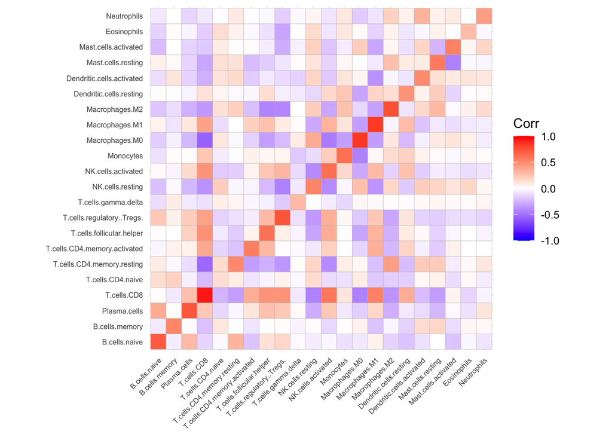

```r
ggcorrplot(t(cormat_LM22_PanCan), tl.cex = 6)
```

```r
cormat_PanCan_SF2018 = cor(cb_PanCan_mtrx, cb_SF2018_mtrx,
                         method = "spearman")

summary(c(cormat_PanCan_SF2018))
```

```
##      Min.   1st Qu.    Median      Mean   3rd Qu.      Max.
## -0.558044 -0.125849 -0.018861  0.001892  0.135396  0.680723
```

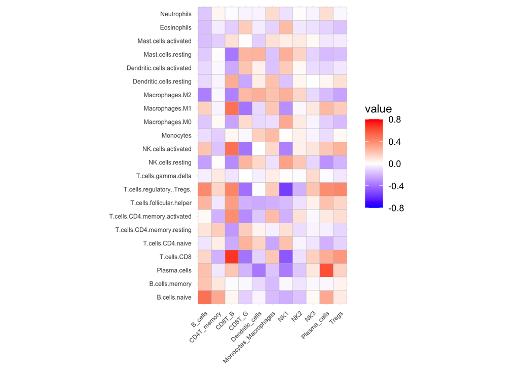

```r
ggcorrplot(t(cormat_PanCan_SF2018), tl.cex = 6) +
  scale_fill_gradient2(limit = c(-0.8, 0.8), low = "blue",
                       high =  "red", mid = "white")
```

```r
cormat_LM22_SF2018 = cor(cb_LM22_mtrx, cb_SF2018_mtrx,
                         method = "spearman")

summary(c(cormat_LM22_SF2018))
```

```
##     Min.  1st Qu.   Median     Mean  3rd Qu.     Max.
## -0.58724 -0.13110 -0.01840 -0.00478  0.11282  0.76764
```

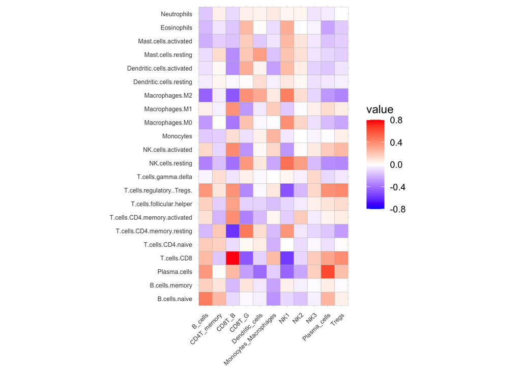

```r
ggcorrplot(t(cormat_LM22_SF2018), tl.cex = 6) +
  scale_fill_gradient2(limit = c(-0.8, 0.8), low = "blue",
                       high =  "red", mid = "white")
```

```r
round(cormat_LM22_SF2018,2)
```

```
##                              B_cells CD4T_memory CD8T_B CD8T_G Dendritic_cells
## B.cells.naive                   0.45        0.24  -0.10  -0.02           -0.04
## B.cells.memory                  0.16        0.09  -0.19   0.09           -0.06
## Plasma.cells                    0.35        0.01   0.24  -0.26           -0.42
## T.cells.CD8                     0.23       -0.15   0.77  -0.48           -0.12
## T.cells.CD4.naive               0.18        0.16  -0.09   0.02            0.06
## T.cells.CD4.memory.resting     -0.19        0.19  -0.59   0.46            0.11
## T.cells.CD4.memory.activated    0.10       -0.20   0.39  -0.35           -0.18
## T.cells.follicular.helper       0.16       -0.13   0.32  -0.12           -0.12
## T.cells.regulatory..Tregs.      0.36        0.09   0.37  -0.33           -0.02
## T.cells.gamma.delta            -0.03        0.11  -0.07   0.05           -0.02
## NK.cells.resting               -0.35       -0.17  -0.40   0.35            0.08
## NK.cells.activated              0.13       -0.11   0.40  -0.30            0.02
## Monocytes                      -0.14       -0.13   0.11  -0.08            0.05
## Macrophages.M0                 -0.28        0.00  -0.38   0.21           -0.02
## Macrophages.M1                  0.05       -0.04   0.37  -0.29           -0.06
## Macrophages.M2                 -0.45       -0.05  -0.48   0.38            0.29
## Dendritic.cells.resting        -0.05        0.03  -0.02   0.01            0.11
## Dendritic.cells.activated      -0.08        0.02  -0.32   0.28            0.04
## Mast.cells.resting             -0.09        0.12  -0.32   0.19            0.33
## Mast.cells.activated           -0.22       -0.13  -0.16   0.17           -0.14
## Eosinophils                    -0.19       -0.07  -0.15   0.24            0.01
## Neutrophils                    -0.15        0.05  -0.10   0.05            0.04
##                              Monocytes_Macrophages   NK1   NK2   NK3
## B.cells.naive                                -0.30 -0.11 -0.16 -0.04
## B.cells.memory                               -0.25  0.05 -0.04 -0.01
## Plasma.cells                                 -0.13 -0.44 -0.24  0.16
## T.cells.CD8                                   0.23 -0.57 -0.11  0.18
## T.cells.CD4.naive                            -0.21  0.00 -0.09 -0.02
## T.cells.CD4.memory.resting                   -0.18  0.36 -0.06 -0.11
## T.cells.CD4.memory.activated                  0.03 -0.13  0.18 -0.05
## T.cells.follicular.helper                    -0.17 -0.11 -0.05  0.05
## T.cells.regulatory..Tregs.                    0.08 -0.49 -0.19  0.13
## T.cells.gamma.delta                           0.00  0.03 -0.04  0.13
## NK.cells.resting                             -0.24  0.49  0.33 -0.18
## NK.cells.activated                            0.13 -0.29  0.01  0.07
## Monocytes                                     0.25 -0.06  0.00 -0.03
## Macrophages.M0                               -0.01  0.38  0.14 -0.08
## Macrophages.M1                                0.17 -0.14 -0.01  0.05
## Macrophages.M2                                0.07  0.44  0.11 -0.11
```

[output cut: 14 more lines]

```
## T.cells.follicular.helper            0.09  0.12
## T.cells.regulatory..Tregs.           0.38  0.40
## T.cells.gamma.delta                 -0.10 -0.06
## NK.cells.resting                    -0.32 -0.33
## NK.cells.activated                   0.18  0.24
## Monocytes                           -0.01  0.05
## Macrophages.M0                      -0.18 -0.24
## Macrophages.M1                       0.12  0.06
## Macrophages.M2                      -0.29 -0.34
## Dendritic.cells.resting             -0.06 -0.04
## Dendritic.cells.activated           -0.15 -0.07
## Mast.cells.resting                  -0.11 -0.13
## Mast.cells.activated                -0.16 -0.13
## Eosinophils                         -0.25 -0.14
## Neutrophils                         -0.05  0.00
```

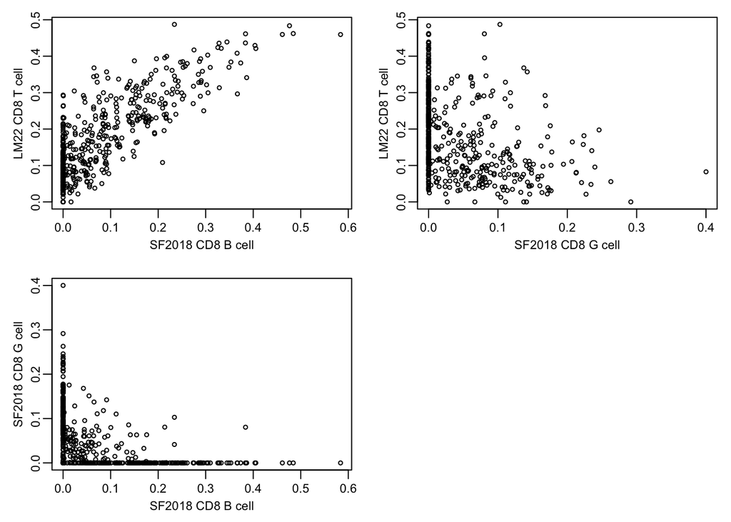

```r
par(mar=c(3,3,1,0.8), mgp=c(1.5,0.5,0), cex.axis=0.85, cex.lab=0.85, cex.main=0.85)
layout(matrix(c(1,2,3,4),nrow=2, ncol = 2,byrow = TRUE))

plot(cb_SF2018$CD8T_B, cb_LM22$T.cells.CD8, cex=0.6,
     xlab = "SF2018 CD8 B cell", ylab = "LM22 CD8 T cell")

plot(cb_SF2018$CD8T_G, cb_LM22$T.cells.CD8, cex=0.6,
     xlab = "SF2018 CD8 G cell", ylab = "LM22 CD8 T cell")

plot(cb_SF2018$CD8T_B, cb_SF2018$CD8T_G, cex=0.6,
     xlab = "SF2018 CD8 B cell", ylab = "SF2018 CD8 G cell")
```

# ICeD-T Results

Read ICeD-T cell fraction estimates.

```r
ic_SF2018_res  = readRDS("ICeDT/SKCM_ICeDT_SF2018.rds")
ic_LM22_res    = readRDS("ICeDT/SKCM_ICeDT_LM22.rds")

lapply(ic_SF2018_res, dim)
```

```
## $rho
## [1]  12 450
##
## $sigma2C
## NULL
##
## $sigma2A
## NULL
##
## $cProp
## NULL
##
## $cProb
## [1] 531 450
```

```r
ic_SF2018 = t(ic_SF2018_res$rho)
ic_SF2018[1:2,c(1:2,11:12)]
```

```
##                  tumor     B_cells Plasma_cells        Tregs
## TCGA.D3.A8GB.06A  0.33 0.047509955   0.03999775 0.0001000112
## TCGA.WE.A8ZN.06A  0.51 0.008092783   0.03072719 0.0001000030
```

```r
lapply(ic_LM22_res, dim)
```

```
## $rho
## [1]  23 450
##
## $sigma2C
## NULL
##
## $sigma2A
## NULL
##
## $cProp
## NULL
##
## $cProb
## [1] 535 450
```

```r
ic_LM22 = t(ic_LM22_res$rho)
ic_LM22[1:2,c(1:2,22:23)]
```

```
##                  tumor B.cells.naive  Eosinophils  Neutrophils
## TCGA.D3.A8GB.06A  0.33  0.0131816430 0.0001000480 9.999998e-05
## TCGA.WE.A8ZN.06A  0.51  0.0001000006 0.0001661053 1.000018e-04
```

```r
summary(ic_LM22[,"tumor"])
```

```
##    Min. 1st Qu.  Median    Mean 3rd Qu.    Max.
##  0.1000  0.4900  0.6900  0.6541  0.8500  0.9800
```

```r
summary(ic_SF2018[,"tumor"])
```

```
##    Min. 1st Qu.  Median    Mean 3rd Qu.    Max.
##  0.1000  0.4900  0.6900  0.6541  0.8500  0.9800
```

```r
summary(rowSums(ic_LM22))
```

```
##    Min. 1st Qu.  Median    Mean 3rd Qu.    Max.
##       1       1       1       1       1       1
```

```r
summary(rowSums(ic_SF2018))
```

```
##    Min. 1st Qu.  Median    Mean 3rd Qu.    Max.
##       1       1       1       1       1       1
```

```r
ic_LM22_mtrx   = data.matrix(ic_LM22[,2:23]/(1 - ic_LM22[,1]))
ic_SF2018_mtrx = data.matrix(ic_SF2018[,2:12]/(1 - ic_SF2018[,1]))
```

Boxplot of cell fraction for each cell type inferred using LM22 signature matrix by ICeD-T

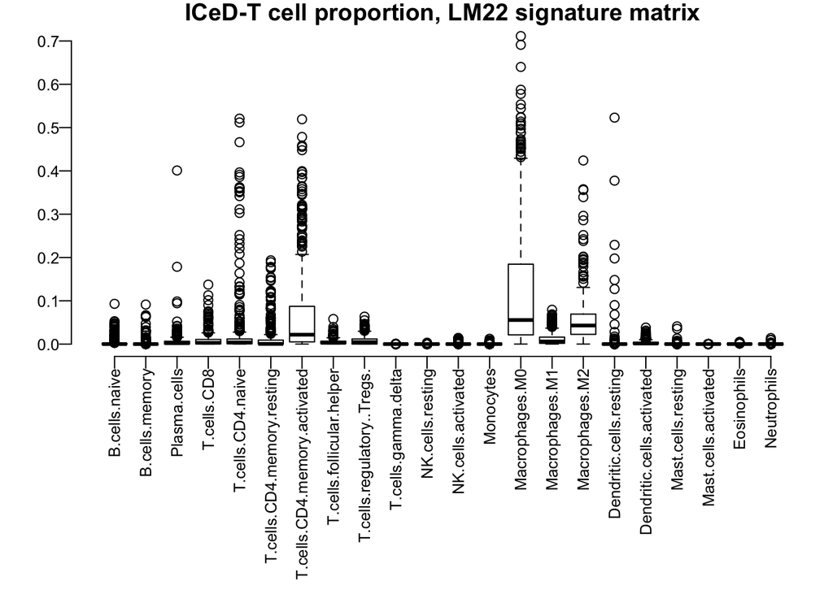

```r
par(mar=c(10,3,1,0.8), mgp=c(1.5,0.5,0), cex.axis=0.8, bty="n")
boxplot(ic_LM22[,2:23],las=2,
        main="ICeD-T cell proportion, LM22 signature matrix")
```

Normalilze the proportion of non-tumor cells so that they add up to be 1.

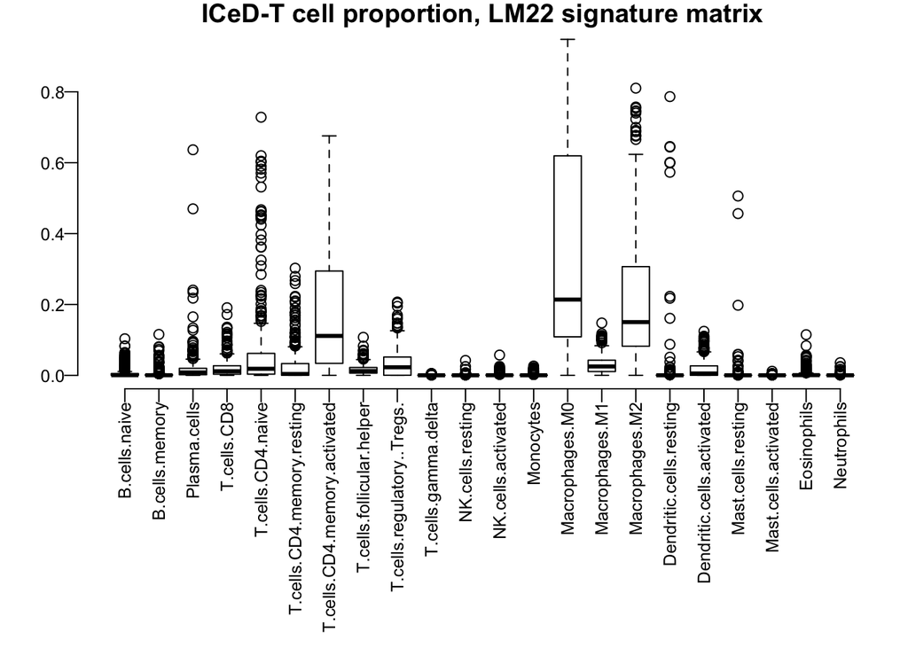

```r
par(mar=c(10,3,1,0.8), mgp=c(1.5,0.5,0), cex.axis=0.8, bty="n")
boxplot(ic_LM22_mtrx, las=2,
        main="ICeD-T cell proportion, LM22 signature matrix")
```

Boxplot of cell fraction for each cell type inferred using SF2018 signature matrix by ICeD-T

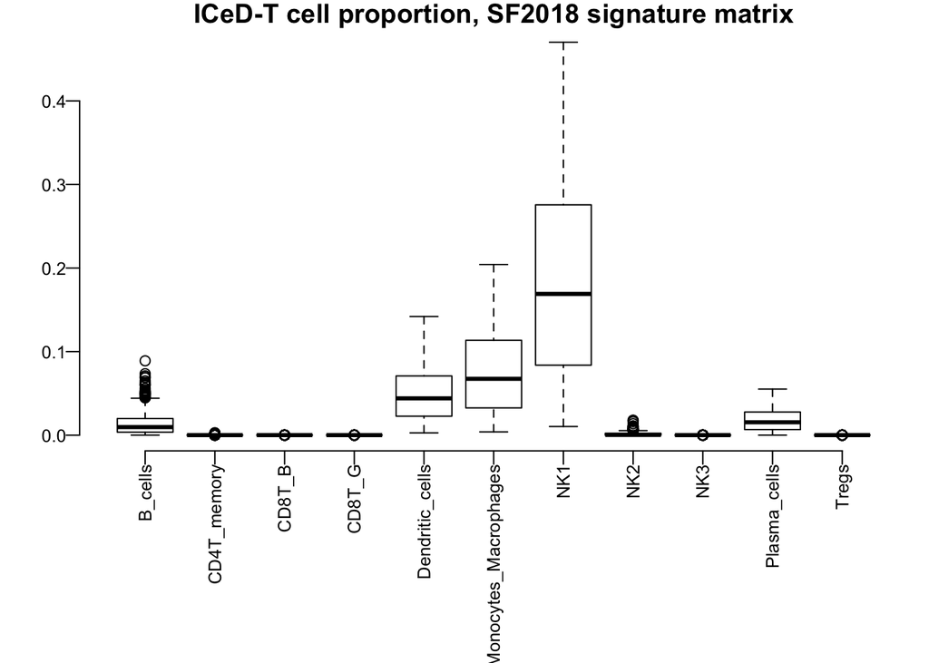

```r
par(mar=c(8,3,1,0.8), mgp=c(1.5,0.5,0), cex.axis=0.8, bty="n")
boxplot(ic_SF2018[,2:12], las=2,
        main="ICeD-T cell proportion, SF2018 signature matrix")
```

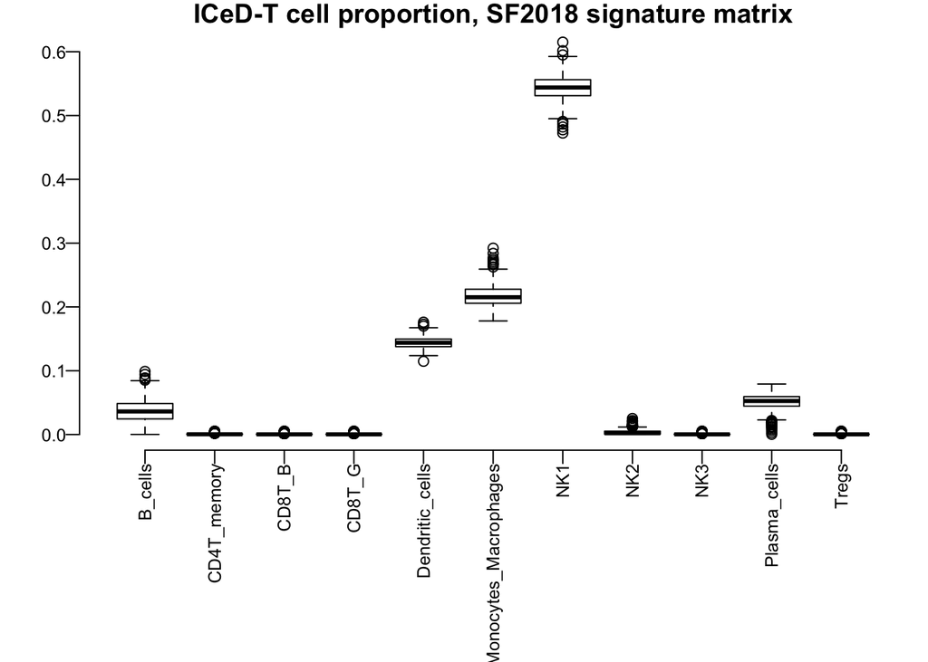

```r
boxplot(ic_SF2018_mtrx, las=2,
        main="ICeD-T cell proportion, SF2018 signature matrix")
```

```r
table(rownames(ic_LM22) == rownames(ic_SF2018))
```

```
##
## TRUE
##  450
```

```r
cormat_LM22_SF2018 = cor(ic_LM22_mtrx, ic_SF2018_mtrx,
                         method = "spearman")

summary(c(cormat_LM22_SF2018))
```

```
##    Min. 1st Qu.  Median    Mean 3rd Qu.    Max.
## -0.5725 -0.1589  0.1732  0.1819  0.5108  0.9997
```

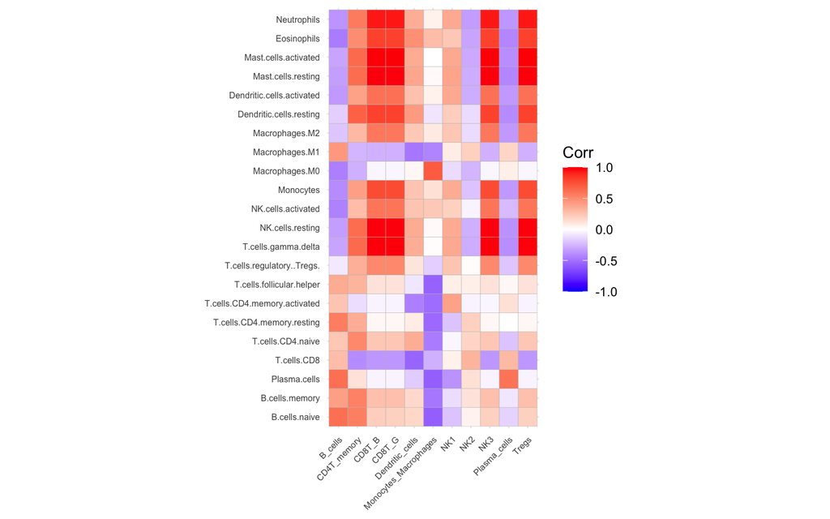

```r
ggcorrplot(t(cormat_LM22_SF2018), tl.cex = 6)
```

```r
round(cormat_LM22_SF2018,2)
```

```
##                              B_cells CD4T_memory CD8T_B CD8T_G Dendritic_cells
## B.cells.naive                   0.62        0.55   0.21   0.20            0.17
## B.cells.memory                  0.41        0.54   0.27   0.27            0.16
## Plasma.cells                    0.62        0.12  -0.04  -0.04           -0.17
## T.cells.CD8                     0.28       -0.40  -0.36  -0.36           -0.55
## T.cells.CD4.naive               0.24        0.51   0.24   0.24            0.35
## T.cells.CD4.memory.resting      0.56        0.35   0.03   0.03            0.08
## T.cells.CD4.memory.activated    0.25       -0.11  -0.04  -0.04           -0.45
## T.cells.follicular.helper       0.36        0.32   0.12   0.12           -0.08
## T.cells.regulatory..Tregs.     -0.07        0.34   0.51   0.51            0.11
## T.cells.gamma.delta            -0.31        0.64   0.99   0.99            0.35
## NK.cells.resting               -0.33        0.63   0.98   0.98            0.36
## NK.cells.activated             -0.44        0.28   0.59   0.59            0.25
## Monocytes                      -0.40        0.41   0.77   0.77            0.25
## Macrophages.M0                 -0.45       -0.27  -0.03  -0.03            0.03
## Macrophages.M1                  0.44       -0.25  -0.26  -0.26           -0.48
## Macrophages.M2                 -0.19        0.30   0.58   0.58            0.23
## Dendritic.cells.resting        -0.16        0.68   0.80   0.80            0.43
## Dendritic.cells.activated      -0.35        0.40   0.61   0.61            0.26
## Mast.cells.resting             -0.33        0.63   0.98   0.98            0.38
## Mast.cells.activated           -0.31        0.64   1.00   1.00            0.36
## Eosinophils                    -0.46        0.49   0.80   0.80            0.48
## Neutrophils                    -0.37        0.57   0.93   0.93            0.35
##                              Monocytes_Macrophages   NK1   NK2   NK3
## B.cells.naive                                -0.57 -0.20  0.05  0.20
## B.cells.memory                               -0.48 -0.11  0.12  0.27
## Plasma.cells                                 -0.57 -0.38  0.13 -0.04
## T.cells.CD8                                  -0.27  0.06  0.32 -0.36
## T.cells.CD4.naive                            -0.46 -0.03  0.18  0.24
## T.cells.CD4.memory.resting                   -0.53 -0.20  0.20  0.03
## T.cells.CD4.memory.activated                 -0.52  0.40 -0.04 -0.03
## T.cells.follicular.helper                    -0.56  0.07  0.07  0.12
## T.cells.regulatory..Tregs.                   -0.16  0.25  0.01  0.51
## T.cells.gamma.delta                           0.01  0.37 -0.28  0.99
## NK.cells.resting                              0.02  0.36 -0.27  0.98
## NK.cells.activated                            0.23  0.20 -0.04  0.59
## Monocytes                                     0.13  0.36 -0.20  0.77
## Macrophages.M0                                0.70 -0.12 -0.25 -0.03
## Macrophages.M1                               -0.43  0.08  0.20 -0.26
## Macrophages.M2                                0.09  0.24 -0.12  0.58
```

[output cut: 14 more lines]

```
## T.cells.follicular.helper            0.03  0.12
## T.cells.regulatory..Tregs.          -0.19  0.51
## T.cells.gamma.delta                 -0.39  0.99
## NK.cells.resting                    -0.38  0.98
## NK.cells.activated                  -0.23  0.59
## Monocytes                           -0.35  0.77
## Macrophages.M0                       0.07 -0.03
## Macrophages.M1                       0.18 -0.26
## Macrophages.M2                      -0.35  0.58
## Dendritic.cells.resting             -0.40  0.80
## Dendritic.cells.activated           -0.35  0.61
## Mast.cells.resting                  -0.42  0.98
## Mast.cells.activated                -0.39  1.00
## Eosinophils                         -0.42  0.80
## Neutrophils                         -0.36  0.93
```

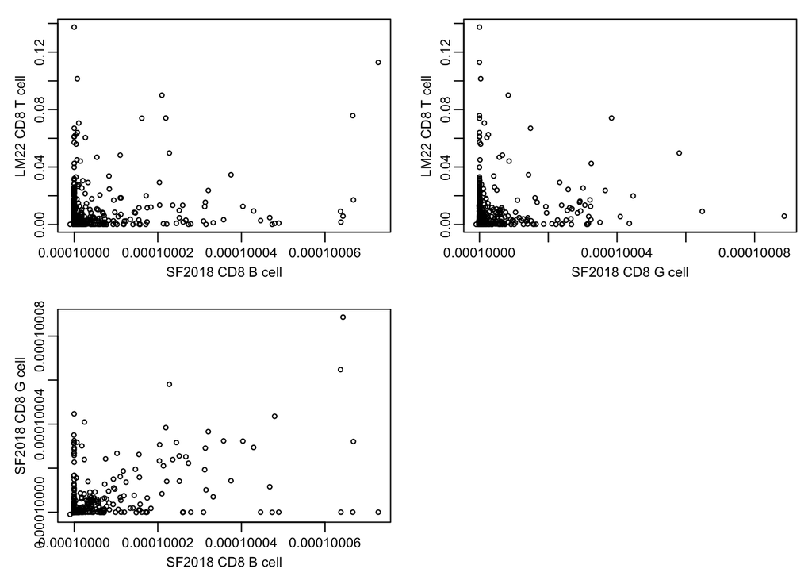

```r
par(mar=c(3,3,1,0.8), mgp=c(1.5,0.5,0), cex.axis=0.85, cex.lab=0.85, cex.main=0.85)
layout(matrix(c(1,2,3,4),nrow=2, ncol = 2,byrow = TRUE))

plot(ic_SF2018[,"CD8T_B"], ic_LM22[,"T.cells.CD8"], cex=0.6,
     xlab = "SF2018 CD8 B cell", ylab = "LM22 CD8 T cell")

plot(ic_SF2018[,"CD8T_G"], ic_LM22[,"T.cells.CD8"], cex=0.6,
     xlab = "SF2018 CD8 G cell", ylab = "LM22 CD8 T cell")

plot(ic_SF2018[,"CD8T_B"], ic_SF2018[,"CD8T_G"], cex=0.6,
     xlab = "SF2018 CD8 B cell", ylab = "SF2018 CD8 G cell")
```

```r
gc()
```

```
##           used (Mb) gc trigger  (Mb) limit (Mb) max used  (Mb)
## Ncells  930995 49.8    2018295 107.8         NA  2018295 107.8
## Vcells 2372896 18.2    8388608  64.0      32768  5001931  38.2
```